# Newborn Prediction ISA

Pasquale Nisi

2024-02-29

Let’s start by importing packages that will be useful for this analysis

```r
library(moments)
library(tibble)
library(dplyr)
library(ggplot2)
library(ggpubr)
library(GGally)
library(car)
library(lmtest)
library(MASS)
library(scatterplot3d)
```

Now we are ready to import our dataset and take a glimpse of it

```r
newborn.df <- read.csv("newborns.csv", stringsAsFactors = T)
newborn.df$Smoker <- as.factor(newborn.df$Smoker)
newborn.df$Hospital <- as.factor(newborn.df$Hospital)
head(newborn.df,10)
```

|  | Mother.Age | Pregnancies.N | Smoker | Gestation | Weight | Length | Cranium | Birth.Type | Hospital | Sex |
| --- | --- | --- | --- | --- | --- | --- | --- | --- | --- | --- |
| 1 | 26 | 0 | 0 | 42 | 3380 | 490 | 325 | Nat | 3 | M |
| 2 | 21 | 2 | 0 | 39 | 3150 | 490 | 345 | Nat | 1 | F |
| 3 | 34 | 3 | 0 | 38 | 3640 | 500 | 375 | Nat | 2 | M |
| 4 | 28 | 1 | 0 | 41 | 3690 | 515 | 365 | Nat | 2 | M |
| 5 | 20 | 0 | 0 | 38 | 3700 | 480 | 335 | Nat | 3 | F |
| 6 | 32 | 0 | 0 | 40 | 3200 | 495 | 340 | Nat | 2 | F |
| 7 | 26 | 1 | 0 | 39 | 3100 | 480 | 345 | Nat | 3 | F |
| 8 | 25 | 0 | 0 | 40 | 3580 | 510 | 349 | Nat | 1 | M |
| 9 | 22 | 1 | 0 | 40 | 3670 | 500 | 335 | Ces | 2 | F |
| 10 | 23 | 0 | 0 | 41 | 3700 | 510 | 362 | Ces | 2 | F |

**Smoker** and **Hospital** are interpreted as numeric but, since we want them as factor, we make conversion using `as.factor`.

The variables in the dataframe are:

- **Mother.Age**: the mother’s age (continuous quantitative variable);
- **Pregnancies.N**: the number of pregnancies the mother has already gone through (discrete quantitative variable);
- **Smoker**: it is 0 if the mother does not smoke, otherwise it is 1 (qualitative nominal variable);
- **Gestation**: number of gestation’s weeks (continuous quantitative variable);
- **Weight**: baby’s weight, in g (continuous quantitative variable);
- **Length**: baby’s length, in mm (continuous quantitative variable);
- **Cranium**: diameter of the baby’s cranium, in mm (continuous quantitative variable);
- **Birth.Type**: birth type, Natural or Cesarean (qualitative nominal variable);
- **Hospital**: hospital, 1, 2 or 3 (qualitative nominal variable);
- **Sex**: baby’s sex, Male or Female (qualitative nominal variable).

The project aims at predicting the baby’s weight, given all the other variables. We will study how the variables influence the weight and see which of them play a relevant role in its determination. To achieve this objective, we use **multiple linear regression**.

Let’s take an explorative analysis of the variables

```r
summary(newborn.df)
```

```
##    Mother.Age    Pregnancies.N     Smoker     Gestation         Weight
##  Min.   : 0.00   Min.   : 0.0000   0:2396   Min.   :25.00   Min.   : 830
##  1st Qu.:25.00   1st Qu.: 0.0000   1: 104   1st Qu.:38.00   1st Qu.:2990
##  Median :28.00   Median : 1.0000            Median :39.00   Median :3300
##  Mean   :28.16   Mean   : 0.9812            Mean   :38.98   Mean   :3284
##  3rd Qu.:32.00   3rd Qu.: 1.0000            3rd Qu.:40.00   3rd Qu.:3620
##  Max.   :46.00   Max.   :12.0000            Max.   :43.00   Max.   :4930
##      Length         Cranium    Birth.Type Hospital Sex
##  Min.   :310.0   Min.   :235   Ces: 728   1:816    F:1256
##  1st Qu.:480.0   1st Qu.:330   Nat:1772   2:849    M:1244
##  Median :500.0   Median :340              3:835
##  Mean   :494.7   Mean   :340
##  3rd Qu.:510.0   3rd Qu.:350
##  Max.   :565.0   Max.   :390
```

**Mother.Age** has a minimum of 0.0 which is clearly not possible. We need to investigate more.

```r
filter(newborn.df, Mother.Age<13)
```

| Mother.Age | Pregnancies.N | Smoker | Gestation | Weight | Length | Cranium | Birth.Type | Hospital | Sex |
| --- | --- | --- | --- | --- | --- | --- | --- | --- | --- |
| 1 | 1 | 0 | 41 | 3250 | 490 | 350 | Nat | 2 | F |
| 0 | 0 | 0 | 39 | 3060 | 490 | 330 | Nat | 3 | M |

With `filter` we see that there are two cases with value for **Mother.Age** that are biologically impossible. Since other variables for these two records have values that seem plausible and we have 2500 observation for each variables, we don’t remove these cases, but make **imputation**. This means we substitute them with the mean or the median of the remaining values.

We use *Shapiro-Wilk normality test* to determine if the variable has a normal distribution (**null hypotesys**) or not. In the first case we can use the mean for imputation, in the latter the median.

```r
age_verified <- subset(newborn.df,Mother.Age>2)$Mother.Age
shapiro.test(age_verified)
```

```
##
##  Shapiro-Wilk normality test
##
## data:  age_verified
## W = 0.99491, p-value = 1.477e-07
```

The results make us refuse the null hypotesis, so we use the median.

```r
median_age <- median(age_verified)

newborn.df$Mother.Age <- replace(newborn.df$Mother.Age,newborn.df$Mother.Age<2,median_age)
summary(newborn.df)
```

```
##    Mother.Age    Pregnancies.N     Smoker     Gestation         Weight
##  Min.   :13.00   Min.   : 0.0000   0:2396   Min.   :25.00   Min.   : 830
##  1st Qu.:25.00   1st Qu.: 0.0000   1: 104   1st Qu.:38.00   1st Qu.:2990
##  Median :28.00   Median : 1.0000            Median :39.00   Median :3300
##  Mean   :28.19   Mean   : 0.9812            Mean   :38.98   Mean   :3284
##  3rd Qu.:32.00   3rd Qu.: 1.0000            3rd Qu.:40.00   3rd Qu.:3620
##  Max.   :46.00   Max.   :12.0000            Max.   :43.00   Max.   :4930
##      Length         Cranium    Birth.Type Hospital Sex
##  Min.   :310.0   Min.   :235   Ces: 728   1:816    F:1256
##  1st Qu.:480.0   1st Qu.:330   Nat:1772   2:849    M:1244
##  Median :500.0   Median :340              3:835
##  Mean   :494.7   Mean   :340
##  3rd Qu.:510.0   3rd Qu.:350
##  Max.   :565.0   Max.   :390
```

Let’s move on and compare the values of **Weight** and **Length** with those of the population. Data of population has been taken from [*https://www.cdc.gov/growthcharts/who_charts.htm*](https://www.cdc.gov/growthcharts/who_charts.htm). In particular:

- Male Weight: 3.520 g
- Female Weight: 3.361 g
- Male Length: 51,5 cm
- Female Length: 50,1 cm

We use the *Student T test* for this comparison

```r
t_weight_F <- t.test(filter(newborn.df, Sex=="F")["Weight"],
                     mu = 3361,
                     conf.level = 0.95,
                     alternative = "two.sided")

t_weight_M <- t.test(filter(newborn.df, Sex=="M")["Weight"],
                     mu = 3520,
                     conf.level = 0.95,
                     alternative = "two.sided")

t_length_F <- t.test(filter(newborn.df, Sex=="F")["Length"],
                     mu = 501,
                     conf.level = 0.95,
                     alternative = "two.sided")

t_length_M <- t.test(filter(newborn.df, Sex=="M")["Length"],
                     mu = 515,
                     conf.level = 0.95,
                     alternative = "two.sided")

t_weight_F$p.value
```

```
## [1] 1.146491e-38
```

```r
t_weight_M$p.value
```

```
## [1] 3.193454e-15
```

```r
t_length_F$p.value
```

```
## [1] 5.864981e-44
```

```r
t_length_M$p.value
```

```
## [1] 2.64661e-94
```

From these we have to reject the null hypotesis and conclude that this dataset don’t belong to the population. Is important to notice that we don’t know when this data has been recorded and, quoting the site, big change have occured in the past 10 years.

We can use a *Two sample T-test* to understand if **Sex** is statistically significant when related to **Weight** and **Length** and visualize it through boxplot

```r
t_test_weight <-t.test(data = newborn.df,
                       Weight ~ Sex,
                       paired = F)
t_test_length <-t.test(data = newborn.df,
                       Length ~ Sex,
                       paired = F)

t_test_weight$p.value
```

```
## [1] 8.029743e-33
```

```r
t_test_length$p.value
```

```
## [1] 2.237243e-21
```

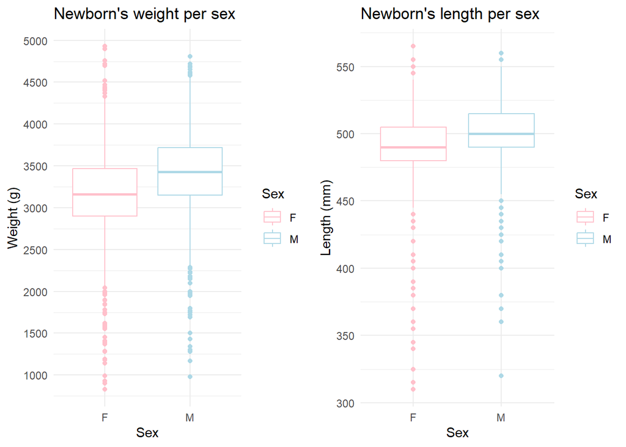

```r
sex_colors <- c("pink", "lightblue")

box_weight <- ggplot(newborn.df, aes(x=Sex,y=Weight))+
  geom_boxplot(aes(color = Sex)
  )+
  scale_color_manual(values = sex_colors)+
  scale_y_continuous(breaks = seq(500,5500,500))+
  labs(x="Sex",
       y="Weight (g)",
       title = "Newborn's weight per sex")+
  theme_minimal()

box_length <- ggplot(newborn.df, aes(x=Sex,y=Length))+
  geom_boxplot(aes(color = Sex))+
  scale_color_manual(values = sex_colors)+
  scale_y_continuous(breaks = seq(300,600,50))+
  labs(x="Sex",
       y="Length (mm)",
       title = "Newborn's length per sex")+
  theme_minimal()

ggarrange(box_weight,box_length,nrow = 1)
```

In both cases, the p-value is very small, therefore we reject the null hypothesis, concluding that the difference between the two mean values is statistically significant.

The last analysis we are going to perform is that regarding the correlation between the birth type and the hospital. To make it let’s create a contingency table and then perform a *Chi Square Test*

```r
hospital_birth_type <- table(newborn.df$Birth.Type,newborn.df$Hospital)
hospital_birth_type
```

```
##
##         1   2   3
##   Ces 242 254 232
##   Nat 574 595 603
```

```r
chisq.test(hospital_birth_type)
```

```
##
##  Pearson's Chi-squared test
##
## data:  hospital_birth_type
## X-squared = 1.0972, df = 2, p-value = 0.5778
```

Let’s visualize it

[figure not shown]

```r
ggballoonplot(data = as.data.frame(hospital_birth_type),
              fill = "value")+
  labs(x="Birth type",
       y="Sex",
       title = "Sex vs birth type",
       fill="Frequency")+
  guides(size=F)+
  theme(plot.title = element_text(hjust = 0.5))
```

Now we investigate the relationship between each variable and the others. In order to simplify this process, let’s divide the dataframe into two subdataframe, one for continuous variables and the other for categorical ones

```r
num_newborn.df <- newborn.df[, sapply(newborn.df, is.numeric)]
fact_newborn.df <- newborn.df[, sapply(newborn.df, is.factor)]
```

To understand the relationship between continuous variables we use the *Correlation Test* and visualize it graphically

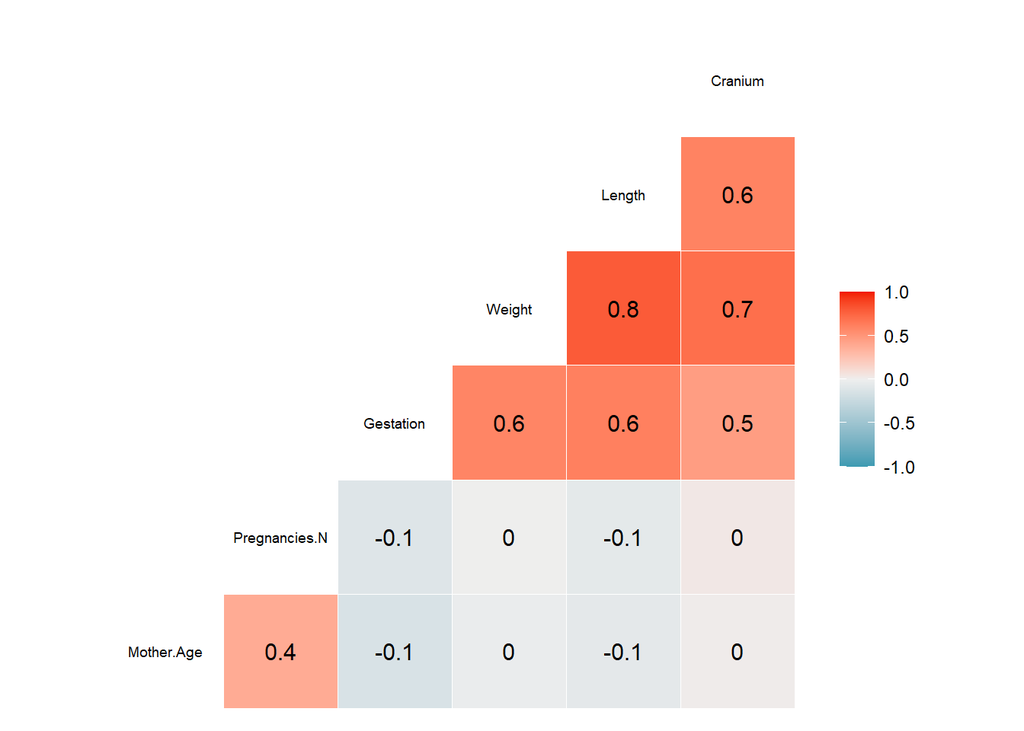

```r
ggcorr(num_newborn.df, label = TRUE, size= 2.5)
```

We find that the **Weight** variable is highly correlated with the variables **Gestation**, **Length** and **Cranium**. **Mother.Age** and **Pregnancies.N** have no correlation at all with **Weight**.

For categorical variables we use the *Chi Square Test*. Let’s create a function to iterate through the dataframe we’ve created and have the p-value of each test as output

```r
chisq_calc <- function(df) {

  results <- data.frame()

  variables <- names(df)

  for (i in 1:(length(variables)-1)) {
    for (j in (i+1):length(variables)) {

      var1 <- df[[variables[i]]]
      var2 <- df[[variables[j]]]

      contingency_table <- table(var1, var2)

      chi_sq_test <- chisq.test(contingency_table)

      p_value <- round(chi_sq_test$p.value, 3)

      results <- rbind(results, c(variables[i], variables[j], p_value))
      }
    }

    colnames(results) <- c("Variable1", "Variable2", "P_Value")

    return(results)

  }

chisq_calc(fact_newborn.df)
```

| Variable1 | Variable2 | P_Value |
| --- | --- | --- |
| Smoker | Birth.Type | 0.404 |
| Smoker | Hospital | 0.698 |
| Smoker | Sex | 0.582 |
| Birth.Type | Hospital | 0.578 |
| Birth.Type | Sex | 0.843 |
| Hospital | Sex | 0.737 |

No P-Value is minor than 0.05, so we can’t reject the null hypothesis and can affirm there is no dependence between the variables.

Last step is to investigate relationship between continuous variables and categorical ones. This time we use the *Student T Test* (or *Pairwise T Test* when one variable is categorical with 3 levels, as **Hospital**)

```r
t_test_calc <- function(df1, df2) {

  variable1 <- names(df1)
  variable2 <- names(df2)

  res <- data.frame()

  for (i in variable1) {
    for (j in variable2){

      var1 <- df1[[i]]
      var2 <- df2[[j]]

      if (nlevels(var2) == 2) {

        test <- t.test(var1 ~ var2,
                       paired = F)
        pval <- round(test$p.value,3)

        res <- bind_rows(res, data.frame(Variable1 = i,
                                         Variable2 = j,
                                         P_Value = pval))

      }
      else {

        test <- pairwise.t.test(var1, var2,
                                paired = F,
                                pool.sd = T,
                                p.adjust.method = "holm")

        pval12 <- round(test$p.value[1,1],3)
        pval13 <- round(test$p.value[2,1],3)
        pval23 <- round(test$p.value[2,2],3)

        lab12 <- paste(j,"1-2")
        lab13 <- paste(j,"1-3")
        lab23 <- paste(j,"2-3")


        res <- bind_rows(res, data.frame(Variable1 = i,
                                         Variable2 = lab12,
                                         P_Value = pval12))

        res <- bind_rows(res, data.frame(Variable1 = i,
                                         Variable2 = lab13,
                                         P_Value = pval13))

        res <- bind_rows(res, data.frame(Variable1 = i,
                                         Variable2 = lab23,
                                         P_Value = pval23))

      }
  }
  }


  return(res)
}


t_test_calc(num_newborn.df,fact_newborn.df)
```

| Variable1 | Variable2 | P_Value |
| --- | --- | --- |
| Mother.Age | Smoker | 0.801 |
| Mother.Age | Birth.Type | 0.923 |
| Mother.Age | Hospital 1-2 | 0.820 |
| Mother.Age | Hospital 1-3 | 0.476 |
| Mother.Age | Hospital 2-3 | 0.476 |
| Mother.Age | Sex | 0.637 |
| Pregnancies.N | Smoker | 0.019 |
| Pregnancies.N | Birth.Type | 0.284 |
| Pregnancies.N | Hospital 1-2 | 0.523 |
| Pregnancies.N | Hospital 1-3 | 0.634 |

[output cut: 26 more lines]

It turns out that **Weight** (the response variable) is highly influenced by **Sex** (we already know it), while it is not significantly dependent on variables **Smoker**, **Birth.Type** and **Hospital**.

It’s time to focus on the main aim of this study. We want to make predictions on newborn weight, so we need to create a *multiple linear regression model* to accomplish that. let’s start from the model containing all the variables

```r
mod1 <- lm(Weight ~ .,data= newborn.df)
summary(mod1)
```

```
##
## Call:
## lm(formula = Weight ~ ., data = newborn.df)
##
## Residuals:
##     Min      1Q  Median      3Q     Max
## -1123.3  -181.2   -14.6   160.7  2612.6
##
## Coefficients:
##                 Estimate Std. Error t value Pr(>|t|)
## (Intercept)   -6735.1677   141.3977 -47.633  < 2e-16 ***
## Mother.Age        0.7983     1.1463   0.696   0.4862
## Pregnancies.N    11.4118     4.6665   2.445   0.0145 *
## Smoker1         -30.1567    27.5396  -1.095   0.2736
## Gestation        32.5265     3.8179   8.520  < 2e-16 ***
## Length           10.2951     0.3007  34.237  < 2e-16 ***
## Cranium          10.4725     0.4261  24.580  < 2e-16 ***
## Birth.TypeNat    29.5027    12.0848   2.441   0.0147 *
## Hospital2       -11.2216    13.4388  -0.835   0.4038
## Hospital3        28.0984    13.4972   2.082   0.0375 *
## SexM             77.5473    11.1779   6.938 5.07e-12 ***
## ---
## Signif. codes:  0 '***' 0.001 '**' 0.01 '*' 0.05 '.' 0.1 ' ' 1
##
## Residual standard error: 273.9 on 2489 degrees of freedom
## Multiple R-squared:  0.7289, Adjusted R-squared:  0.7278
## F-statistic: 669.1 on 10 and 2489 DF,  p-value: < 2.2e-16
```

From this model we can see R^2 is quite good but some variables have coefficients with an high value (>0.05), which means their significance is low.

To find the best model we remove time after time variables which have highest value for coefficients and the update the model. First to eliminate is **Mother.Age**

```r
mod2 <- update(mod1,~.-Mother.Age)
summary(mod2)
```

```
##
## Call:
## lm(formula = Weight ~ Pregnancies.N + Smoker + Gestation + Length +
##     Cranium + Birth.Type + Hospital + Sex, data = newborn.df)
##
## Residuals:
##      Min       1Q   Median       3Q      Max
## -1113.93  -180.11   -16.36   160.58  2616.96
##
## Coefficients:
##                 Estimate Std. Error t value Pr(>|t|)
## (Intercept)   -6708.1065   135.9394 -49.346  < 2e-16 ***
## Pregnancies.N    12.6085     4.3381   2.906  0.00369 **
## Smoker1         -30.3092    27.5359  -1.101  0.27113
## Gestation        32.2501     3.7968   8.494  < 2e-16 ***
## Length           10.2944     0.3007  34.239  < 2e-16 ***
## Cranium          10.4876     0.4255  24.651  < 2e-16 ***
## Birth.TypeNat    29.5351    12.0834   2.444  0.01458 *
## Hospital2       -11.0816    13.4359  -0.825  0.40957
## Hospital3        28.3660    13.4903   2.103  0.03559 *
## SexM             77.6205    11.1763   6.945 4.81e-12 ***
## ---
## Signif. codes:  0 '***' 0.001 '**' 0.01 '*' 0.05 '.' 0.1 ' ' 1
##
## Residual standard error: 273.9 on 2490 degrees of freedom
## Multiple R-squared:  0.7288, Adjusted R-squared:  0.7278
## F-statistic: 743.6 on 9 and 2490 DF,  p-value: < 2.2e-16
```

Now it’s **Hospital** that has the highest value. Let’s remove it

```r
mod3 <- update(mod2,~.-Hospital)
summary(mod3)
```

```
##
## Call:
## lm(formula = Weight ~ Pregnancies.N + Smoker + Gestation + Length +
##     Cranium + Birth.Type + Sex, data = newborn.df)
##
## Residuals:
##      Min       1Q   Median       3Q      Max
## -1130.04  -181.29   -16.31   160.59  2635.32
##
## Coefficients:
##                Estimate Std. Error t value Pr(>|t|)
## (Intercept)   -6708.074    135.984 -49.330  < 2e-16 ***
## Pregnancies.N    13.012      4.342   2.997  0.00276 **
## Smoker1         -31.759     27.570  -1.152  0.24946
## Gestation        32.541      3.801   8.561  < 2e-16 ***
## Length           10.272      0.301  34.129  < 2e-16 ***
## Cranium          10.501      0.426  24.648  < 2e-16 ***
## Birth.TypeNat    30.296     12.098   2.504  0.01234 *
## SexM             78.114     11.191   6.980 3.77e-12 ***
## ---
## Signif. codes:  0 '***' 0.001 '**' 0.01 '*' 0.05 '.' 0.1 ' ' 1
##
## Residual standard error: 274.3 on 2492 degrees of freedom
## Multiple R-squared:  0.7278, Adjusted R-squared:  0.7271
## F-statistic:   952 on 7 and 2492 DF,  p-value: < 2.2e-16
```

Same for **Smoker**

```r
mod4 <- update(mod3,~.-Smoker)
summary(mod4)
```

```
##
## Call:
## lm(formula = Weight ~ Pregnancies.N + Gestation + Length + Cranium +
##     Birth.Type + Sex, data = newborn.df)
##
## Residuals:
##      Min       1Q   Median       3Q      Max
## -1129.31  -181.70   -16.31   161.07  2638.85
##
## Coefficients:
##                 Estimate Std. Error t value Pr(>|t|)
## (Intercept)   -6707.2971   135.9911 -49.322  < 2e-16 ***
## Pregnancies.N    12.7558     4.3366   2.941   0.0033 **
## Gestation        32.2713     3.7941   8.506  < 2e-16 ***
## Length           10.2864     0.3007  34.207  < 2e-16 ***
## Cranium          10.5057     0.4260  24.659  < 2e-16 ***
## Birth.TypeNat    30.0342    12.0969   2.483   0.0131 *
## SexM             77.9285    11.1905   6.964 4.22e-12 ***
## ---
## Signif. codes:  0 '***' 0.001 '**' 0.01 '*' 0.05 '.' 0.1 ' ' 1
##
## Residual standard error: 274.3 on 2493 degrees of freedom
## Multiple R-squared:  0.7277, Adjusted R-squared:  0.727
## F-statistic:  1110 on 6 and 2493 DF,  p-value: < 2.2e-16
```

And now it’s the turn of **Birth.Type**

```r
mod5 <- update(mod4,~.-Birth.Type)
summary(mod5)
```

```
##
## Call:
## lm(formula = Weight ~ Pregnancies.N + Gestation + Length + Cranium +
##     Sex, data = newborn.df)
##
## Residuals:
##      Min       1Q   Median       3Q      Max
## -1149.44  -180.81   -15.58   163.64  2639.72
##
## Coefficients:
##                 Estimate Std. Error t value Pr(>|t|)
## (Intercept)   -6681.1445   135.7229 -49.226  < 2e-16 ***
## Pregnancies.N    12.4750     4.3396   2.875  0.00408 **
## Gestation        32.3321     3.7980   8.513  < 2e-16 ***
## Length           10.2486     0.3006  34.090  < 2e-16 ***
## Cranium          10.5402     0.4262  24.728  < 2e-16 ***
## SexM             77.9927    11.2021   6.962 4.26e-12 ***
## ---
## Signif. codes:  0 '***' 0.001 '**' 0.01 '*' 0.05 '.' 0.1 ' ' 1
##
## Residual standard error: 274.6 on 2494 degrees of freedom
## Multiple R-squared:  0.727,  Adjusted R-squared:  0.7265
## F-statistic:  1328 on 5 and 2494 DF,  p-value: < 2.2e-16
```

R<sup>2</sup> value has not changed a lot during these updates, but now we have all included variables to be relevant. **mod5** seems to be a good candidate, Let’s see if we have the same result using `BIC` and `AIC` function.

```r
BIC(mod1,mod2,mod3,mod4,mod5)
```

|  | df | BIC |
| --- | --- | --- |
| mod1 | 12 | 35241.97 |
| mod2 | 11 | 35234.64 |
| mod3 | 9 | 35228.24 |
| mod4 | 8 | 35221.75 |
| mod5 | 7 | 35220.10 |

```r
AIC(mod1,mod2,mod3,mod4,mod5)
```

|  | df | AIC |
| --- | --- | --- |
| mod1 | 12 | 35172.09 |
| mod2 | 11 | 35170.57 |
| mod3 | 9 | 35175.83 |
| mod4 | 8 | 35175.16 |
| mod5 | 7 | 35179.33 |

Let’s take a look to residuals of this model

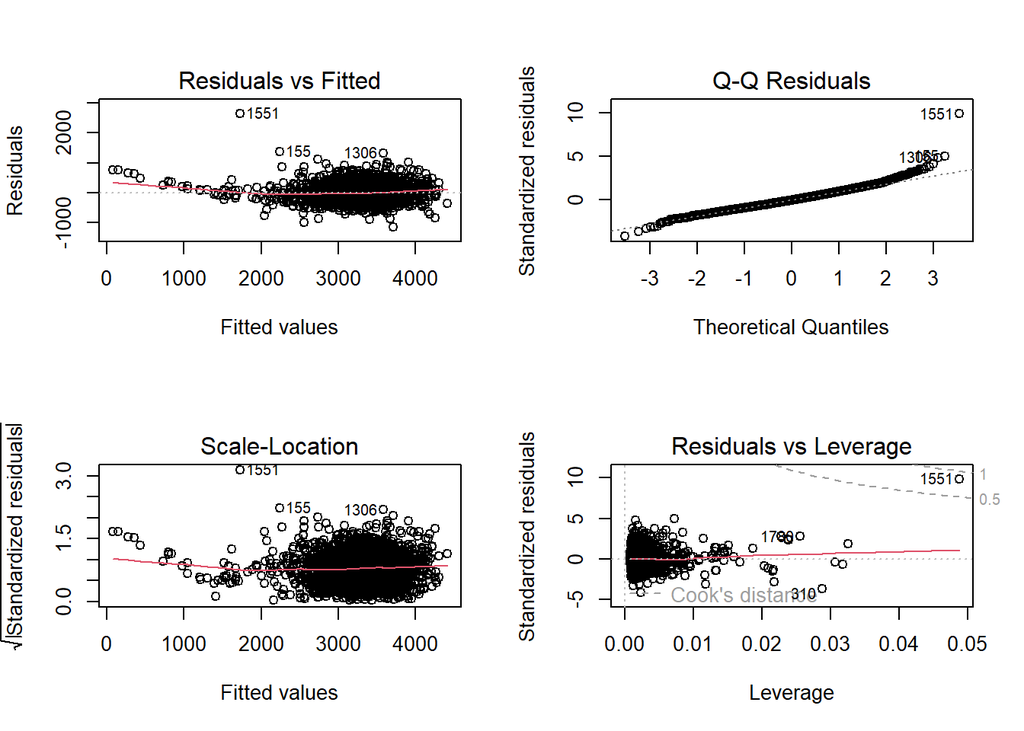

```r
par(mfrow=c(2,2))

plot(mod5)
```

From this plots seems to be non-linear effects between variables. Update the model adding the quadratic terms of the variables included in **mod5**

```r
mod6 <- update(mod5,~.+I(Gestation^2)+I(Length^2)+I(Cranium^2))
summary(mod6)
```

```
##
## Call:
## lm(formula = Weight ~ Pregnancies.N + Gestation + Length + Cranium +
##     Sex + I(Gestation^2) + I(Length^2) + I(Cranium^2), data = newborn.df)
##
## Residuals:
##      Min       1Q   Median       3Q      Max
## -1187.03  -182.50   -12.03   162.60  1469.62
##
## Coefficients:
##                  Estimate Std. Error t value Pr(>|t|)
## (Intercept)    -1.217e+03  1.160e+03  -1.049   0.2945
## Pregnancies.N   1.441e+01  4.246e+00   3.394   0.0007 ***
## Gestation       3.754e+02  6.738e+01   5.572 2.79e-08 ***
## Length         -2.925e+01  4.436e+00  -6.592 5.28e-11 ***
## Cranium        -4.979e+00  9.804e+00  -0.508   0.6116
## SexM            7.232e+01  1.100e+01   6.577 5.83e-11 ***
## I(Gestation^2) -4.374e+00  8.834e-01  -4.951 7.86e-07 ***
## I(Length^2)     4.075e-02  4.544e-03   8.967  < 2e-16 ***
## I(Cranium^2)    2.276e-02  1.445e-02   1.575   0.1154
## ---
## Signif. codes:  0 '***' 0.001 '**' 0.01 '*' 0.05 '.' 0.1 ' ' 1
##
## Residual standard error: 268.4 on 2491 degrees of freedom
## Multiple R-squared:  0.7395, Adjusted R-squared:  0.7387
## F-statistic: 883.9 on 8 and 2491 DF,  p-value: < 2.2e-16
```

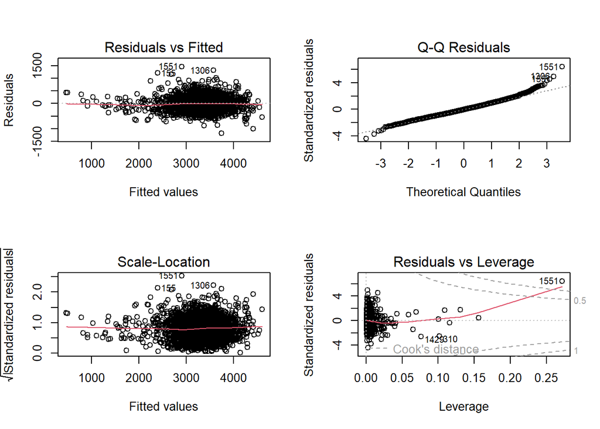

```r
par(mfrow=c(2,2))

plot(mod6)
```

Residuals (top left plot) has a more horizontal line than the previous one. However *Cranium* has lost significance and also its quadratic terms has low significance. We can try to remove the quadratic term and see what happens to the model

```r
mod7 <- update(mod6,~.-I(Cranium^2))
summary(mod7)
```

```
##
## Call:
## lm(formula = Weight ~ Pregnancies.N + Gestation + Length + Cranium +
##     Sex + I(Gestation^2) + I(Length^2), data = newborn.df)
##
## Residuals:
##      Min       1Q   Median       3Q      Max
## -1191.07  -182.28   -13.74   163.34  1403.53
##
## Coefficients:
##                  Estimate Std. Error t value Pr(>|t|)
## (Intercept)    -2.360e+03  9.053e+02  -2.607  0.00919 **
## Pregnancies.N   1.448e+01  4.247e+00   3.410  0.00066 ***
## Gestation       3.365e+02  6.270e+01   5.367 8.74e-08 ***
## Length         -3.215e+01  4.037e+00  -7.963 2.53e-15 ***
## Cranium         1.045e+01  4.192e-01  24.922  < 2e-16 ***
## SexM            7.261e+01  1.100e+01   6.602 4.93e-11 ***
## I(Gestation^2) -3.873e+00  8.245e-01  -4.698 2.77e-06 ***
## I(Length^2)     4.370e-02  4.140e-03  10.556  < 2e-16 ***
## ---
## Signif. codes:  0 '***' 0.001 '**' 0.01 '*' 0.05 '.' 0.1 ' ' 1
##
## Residual standard error: 268.5 on 2492 degrees of freedom
## Multiple R-squared:  0.7392, Adjusted R-squared:  0.7385
## F-statistic:  1009 on 7 and 2492 DF,  p-value: < 2.2e-16
```

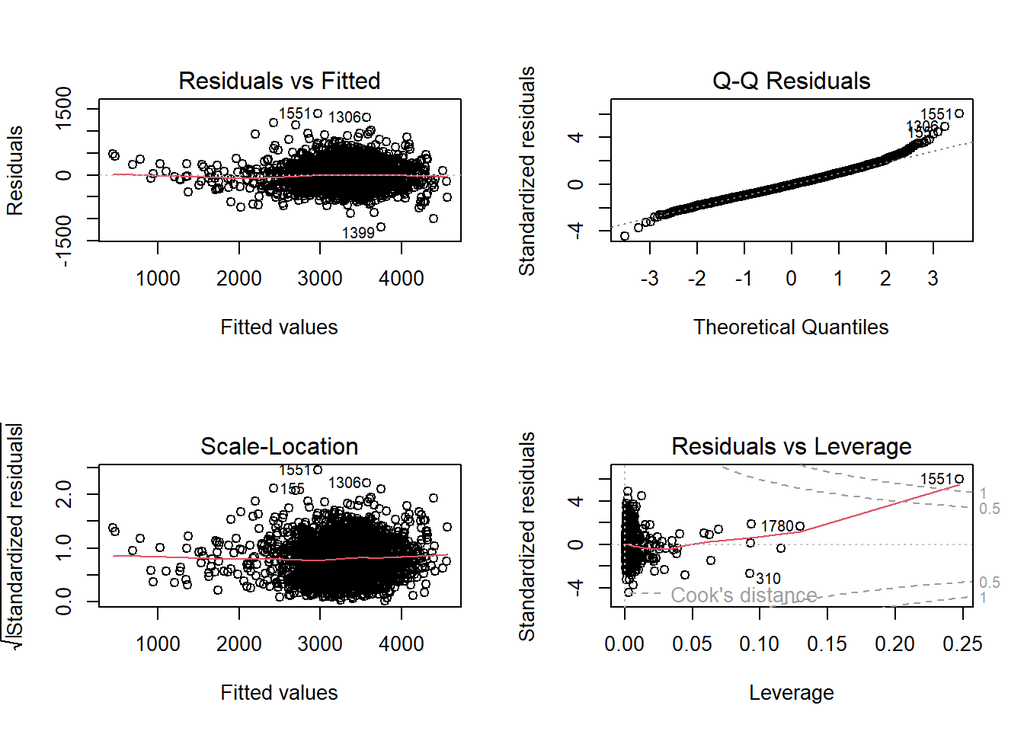

```r
par(mfrow=c(2,2))
plot(mod7)
```

With this update *Cranium* has come back to have a good value of significance, while only slightly happens to the plots. At this point, **mod7** is the main candidate. let’s use again `BIC` and `AIC` function to see if we can confirm that

```r
BIC(mod5,mod6,mod7)
```

|  | df | BIC |
| --- | --- | --- |
| mod5 | 7 | 35220.10 |
| mod6 | 10 | 35126.48 |
| mod7 | 9 | 35121.14 |

```r
AIC(mod5,mod6,mod7)
```

|  | df | AIC |
| --- | --- | --- |
| mod5 | 7 | 35179.33 |
| mod6 | 10 | 35068.24 |
| mod7 | 9 | 35068.73 |

`BIC` give us confirmation on the choice of the model, instead `AIC` prefer slightly **mod6**. This happens because `BIC` gives a heavier penalty on models with many variables. Since the difference between **mod6** and **mod7** is negligible, if compared, for example, to the difference between **mod5** and **mod6**, we choose **mod7** as the best model, since it is simplier (less parameters).

Let’s compute the variance inflation factors (VIFs) of **mod7** to evaluate if there is presence of *multicollinearity*

```r
vif(mod7, type="predictor")
```

|  | GVIF | Df | GVIF^(1/(2*Df)) | Interacts With | Other Predictors |
| --- | --- | --- | --- | --- | --- |
| Pregnancies.N | 1.025434 | 1 | 1.012637 | -- | Gestation, Length, Cranium, Sex |
| Gestation | 3.100126 | 2 | 1.326920 | I(Gestation^2) | Pregnancies.N, Length, Cranium, Sex |
| Length | 3.746905 | 2 | 1.391292 | I(Length^2) | Pregnancies.N, Gestation, Cranium, Sex |
| Cranium | 1.643288 | 1 | 1.281908 | -- | Pregnancies.N, Gestation, Length, Sex |
| Sex | 1.048541 | 1 | 1.023983 | -- | Pregnancies.N, Gestation, Length, Cranium |

The results show us no parameters above 5, so we can conclude there is no multicollinearity.

We can investigate the mean of residuals of **mod7** to see if is 0, which means a normal distribution

```r
mean(residuals(mod7))
```

```
## [1] 1.461354e-14
```

```r
sd(residuals(mod7))
```

```
## [1] 268.1125
```

Result says it is approxiamtely 0, so we can confirm this point.

Let’s test the hypothesis of *homoscedasticity* by means of the *Breusch-Pagan Test*

```r
bptest(mod7)
```

```
##
##  studentized Breusch-Pagan test
##
## data:  mod7
## BP = 97.553, df = 7, p-value < 2.2e-16
```

We have to reject the null hypothesis, thus we conclude that the residuals are heteroscedastic, meaning that they do not have a constant variance.

Let us now perform the *Durbin-Watson Test* to verify the hypothesis of independence of the residuals:

```r
dwtest(mod7)
```

```
##
##  Durbin-Watson test
##
## data:  mod7
## DW = 1.9494, p-value = 0.1028
## alternative hypothesis: true autocorrelation is greater than 0
```

This outputs lead us not to reject the null hypothesis, so we can affirm errors are uncorrelated.

Last but not least, we take a look at **outliers**, which are points that as a response variable (**Weight** in this case) which is far from that predicted by the model, and **leverages**, which are observation with unusual value in the variables. Points with outliers or high leverage can distort the outcome and accuracy of a regression analysis. *Cook Distance* is the statistic we can use to determine the influence of this points.

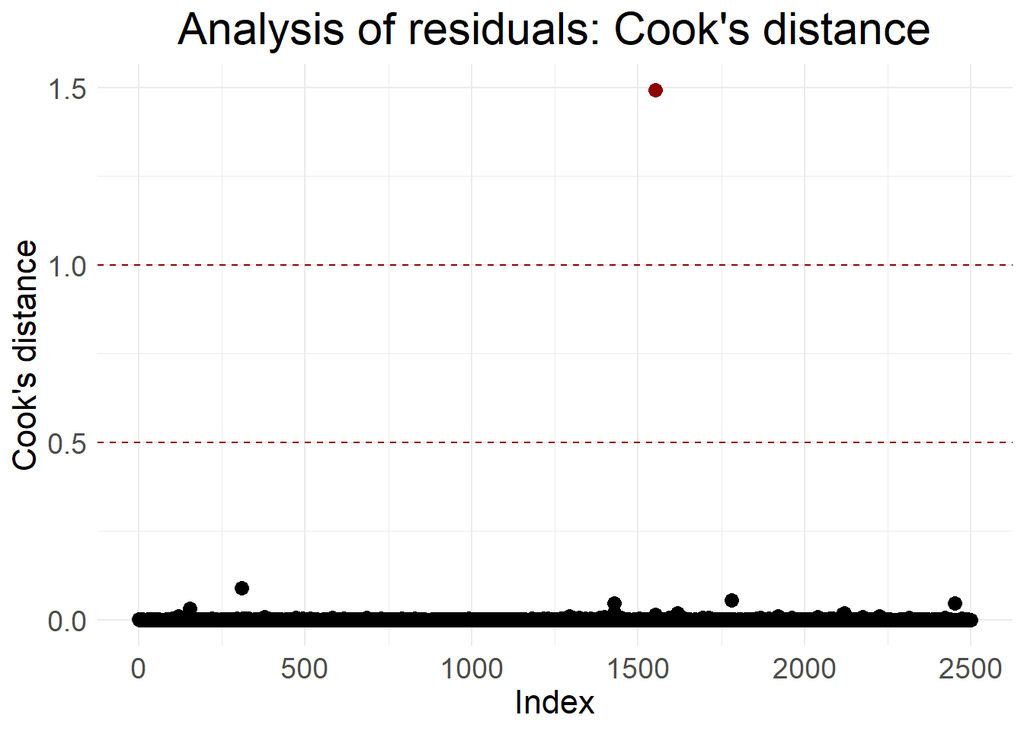

```r
cook <- cooks.distance(mod7)
ggplot()+
  geom_point(aes(x=1:length(cook),
                 y=cook,
                 colour = cook>1),
             size = 3)+
  geom_hline(aes(yintercept=c(0.5,1)),
             linetype=2,
             colour = "darkred")+
  scale_colour_manual(values = setNames(c("darkred","black"),c(T,F)))+
  labs(title = "Analysis of residuals: Cook's distance",
       x = "Index",
       y = "Cook's distance")+
  theme_minimal()+
  theme(plot.title = element_text(size = 22, hjust = 0.5),
        axis.text.x = element_text(size = 14),
        axis.text.y = element_text(size = 14),
        axis.title = element_text(size = 16),
        legend.position = "none")
```

It seems that the only value having a Cook’s distance bigger than the critical value of 1 is the observation **1551**. We can try to remove it from our dataframe and recreate the model

```r
index <- match(max(cook),cook)

corrected_nb.df <- newborn.df[-index,]
mod8 <- lm(Weight ~ Pregnancies.N + Gestation +
             Length + Cranium + Sex + I(Gestation^2) + I(Length^2),
           data = corrected_nb.df)
summary(mod8)
```

```
##
## Call:
## lm(formula = Weight ~ Pregnancies.N + Gestation + Length + Cranium +
##     Sex + I(Gestation^2) + I(Length^2), data = corrected_nb.df)
##
## Residuals:
##      Min       1Q   Median       3Q      Max
## -1187.72  -180.63   -13.61   164.12  1320.11
##
## Coefficients:
##                  Estimate Std. Error t value Pr(>|t|)
## (Intercept)    -2.811e+03  9.019e+02  -3.117 0.001848 **
## Pregnancies.N   1.440e+01  4.217e+00   3.414 0.000651 ***
## Gestation       2.004e+02  6.617e+01   3.028 0.002489 **
## Length         -1.928e+01  4.535e+00  -4.252 2.20e-05 ***
## Cranium         1.009e+01  4.202e-01  24.023  < 2e-16 ***
## SexM            7.340e+01  1.092e+01   6.721 2.22e-11 ***
## I(Gestation^2) -2.135e+00  8.673e-01  -2.462 0.013890 *
## I(Length^2)     3.093e-02  4.618e-03   6.697 2.62e-11 ***
## ---
## Signif. codes:  0 '***' 0.001 '**' 0.01 '*' 0.05 '.' 0.1 ' ' 1
##
## Residual standard error: 266.6 on 2491 degrees of freedom
## Multiple R-squared:  0.7426, Adjusted R-squared:  0.7419
## F-statistic:  1027 on 7 and 2491 DF,  p-value: < 2.2e-16
```

After these passages R^2 is increased, but the same occurred to p-value of quadratic term of *Gestation*. Although it has still significance we can try to remove it and observe the outputs of the model

```r
mod9 <- update(mod8,~.-I(Gestation^2))
summary(mod9)
```

```
##
## Call:
## lm(formula = Weight ~ Pregnancies.N + Gestation + Length + Cranium +
##     Sex + I(Length^2), data = corrected_nb.df)
##
## Residuals:
##      Min       1Q   Median       3Q      Max
## -1176.79  -178.89   -12.52   164.19  1327.44
##
## Coefficients:
##                 Estimate Std. Error t value Pr(>|t|)
## (Intercept)   -1.607e+03  7.586e+02  -2.119 0.034207 *
## Pregnancies.N  1.420e+01  4.220e+00   3.364 0.000781 ***
## Gestation      3.773e+01  3.890e+00   9.700  < 2e-16 ***
## Length        -1.172e+01  3.342e+00  -3.508 0.000459 ***
## Cranium        1.015e+01  4.201e-01  24.157  < 2e-16 ***
## SexM           7.222e+01  1.092e+01   6.614 4.57e-11 ***
## I(Length^2)    2.330e-02  3.430e-03   6.795 1.35e-11 ***
## ---
## Signif. codes:  0 '***' 0.001 '**' 0.01 '*' 0.05 '.' 0.1 ' ' 1
##
## Residual standard error: 266.8 on 2492 degrees of freedom
## Multiple R-squared:  0.742,  Adjusted R-squared:  0.7413
## F-statistic:  1194 on 6 and 2492 DF,  p-value: < 2.2e-16
```

Now all parameters have the same high level of significance although R<sup>2</sup> decreased slightly. We can make a comparison among the last three model

```r
BIC(mod7,mod8,mod9)
```

|  | df | BIC |
| --- | --- | --- |
| mod7 | 9 | 35121.14 |
| mod8 | 9 | 35071.44 |
| mod9 | 8 | 35069.69 |

```r
AIC(mod7,mod8,mod9)
```

|  | df | AIC |
| --- | --- | --- |
| mod7 | 9 | 35068.73 |
| mod8 | 9 | 35019.02 |
| mod9 | 8 | 35023.10 |

As occurred previously, BIC highlights **mod9** as the best model since ithas less parameters, instead AIC prefer **mod8**. As before we choose **mod9** since is simplier.

We can now investigate residuals as done for **mod7**

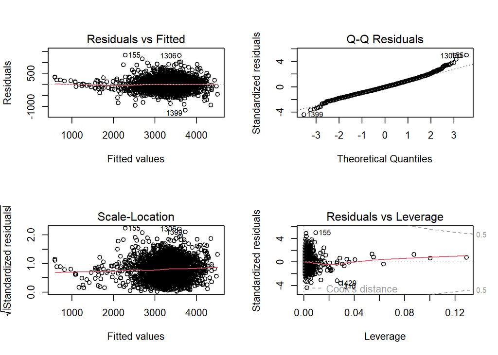

```r
par(mfrow=c(2,2))
plot(mod9)
```

```r
dwtest(mod9)
```

```
##
##  Durbin-Watson test
##
## data:  mod9
## DW = 1.9498, p-value = 0.1046
## alternative hypothesis: true autocorrelation is greater than 0
```

```r
bptest(mod9)
```

```
##
##  studentized Breusch-Pagan test
##
## data:  mod9
## BP = 15.47, df = 6, p-value = 0.0169
```

This time we can assume the **homoskedasticity** of residuals. Indeed the *Breusch-Pagan Test* has an higher p-value and we can set the level of significance to 0.01 (instead of 0.05). Uncorrelation guaranteed as before. We can conclude **mod9** is the best model we can achieve and it can be reliable in predicting weight of newborns.

It’s time to test our model. Let’s make a prediction for a newborn’s weight. For example, let us consider a mother that:

- has already gone through 3 pregnancies;
- will deliver her baby during the 39th week.

Let us also suppose that we do not have information about the length and the diameter of the cranium. In this case, we can use the female related mean values to give an estimate of these parameters

```r
prediction = predict(mod9,
            newdata = data.frame(Sex="F",Gestation=39,Pregnancies.N=3,
                                 Length=mean(newborn.df$Length[newborn.df$Sex=="F"]),
                                 Cranium=mean(newborn.df$Cranium[newborn.df$Sex=="F"])),
            interval = "predict")

prediction
```

```
##        fit      lwr      upr
## 1 3180.961 2657.185 3704.736
```

The two values in the output represent the extreme values of the corresponding 95% prediction interval.

```r
prediction[3] - prediction[1]
```

```
## [1] 523.7752
```

```r
prediction[1] - prediction[2]
```

```
## [1] 523.7752
```

We can affirm that this baby will have a weight of **3180.96 $\pm$ 523.77 g**

In the end, after we have make our prediction, we can try to visualized a simplified version of our data in a 3D scatterplot

```r
par(mfrow=c(1,1))
colors <- c("lightblue", "coral")
colors <- colors[as.numeric(newborn.df$Sex)]
s3d <- scatterplot3d(newborn.df$Weight~newborn.df$Pregnancies.N+newborn.df$Length,
                     color = colors,
                     pch = 16,
                     angle = 50,
                     main = "3D Scatter plot",
                     xlab = "Number of Pregnancies",
                     ylab = "Length (mm)",
                     zlab = "Weight (g)",
                     grid = T,
                     box = F)
legend("right", legend = levels(newborn.df$Sex),
       col =  colors,
       pch = 16,
       xpd = TRUE,
       xjust = 0,
       cex = 0.8,
       box.lty = 0,
       bg = "transparent")
F_data <- filter(newborn.df, Hospital=="1")
M_data <- filter(newborn.df, Hospital=="2")
F_lm <- lm(Weight ~ Pregnancies.N + Length, data = F_data)
M_lm <- lm(Weight ~ Pregnancies.N + Length, data = M_data)
summary(F_lm)
```

```
##
## Call:
## lm(formula = Weight ~ Pregnancies.N + Length, data = F_data)
##
## Residuals:
##      Min       1Q   Median       3Q      Max
## -1007.94  -219.85   -21.27   206.93  1683.05
##
## Coefficients:
##                 Estimate Std. Error t value Pr(>|t|)
## (Intercept)   -4531.2354   206.0524 -21.991   <2e-16 ***
## Pregnancies.N    18.3707     8.7092   2.109   0.0352 *
## Length           15.7517     0.4145  38.005   <2e-16 ***
## ---
## Signif. codes:  0 '***' 0.001 '**' 0.01 '*' 0.05 '.' 0.1 ' ' 1
##
## Residual standard error: 320.8 on 813 degrees of freedom
## Multiple R-squared:  0.6401, Adjusted R-squared:  0.6392
## F-statistic:   723 on 2 and 813 DF,  p-value: < 2.2e-16
```

```r
summary(M_lm)
```

```
##
## Call:
## lm(formula = Weight ~ Pregnancies.N + Length, data = M_data)
##
## Residuals:
##     Min      1Q  Median      3Q     Max
## -1459.1  -191.6   -18.2   179.2  1399.3
##
## Coefficients:
##                 Estimate Std. Error t value Pr(>|t|)
## (Intercept)   -4969.4271   204.9905 -24.242   <2e-16 ***
## Pregnancies.N    14.4663     8.1340   1.779   0.0757 .
## Length           16.6081     0.4117  40.337   <2e-16 ***
## ---
## Signif. codes:  0 '***' 0.001 '**' 0.01 '*' 0.05 '.' 0.1 ' ' 1
##
## Residual standard error: 306.4 on 846 degrees of freedom
## Multiple R-squared:  0.6583, Adjusted R-squared:  0.6575
## F-statistic: 814.9 on 2 and 846 DF,  p-value: < 2.2e-16
```

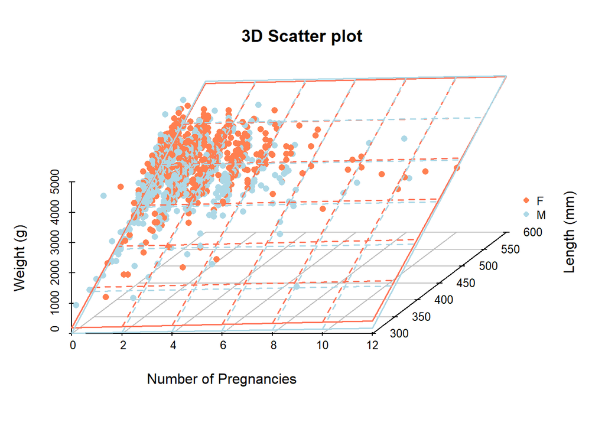

```r
s3d$plane3d(F_lm, lty.box = "solid", col = "coral1", lwd = 1.5)
s3d$plane3d(M_lm, lty.box = "solid", col = "lightblue", lwd = 1.5)
```